# Analiza wody pod względem tego, czy jest zdatna do picia

Czyszczenie danych, wizualizacja, model przewiwydwania

2022-04-05

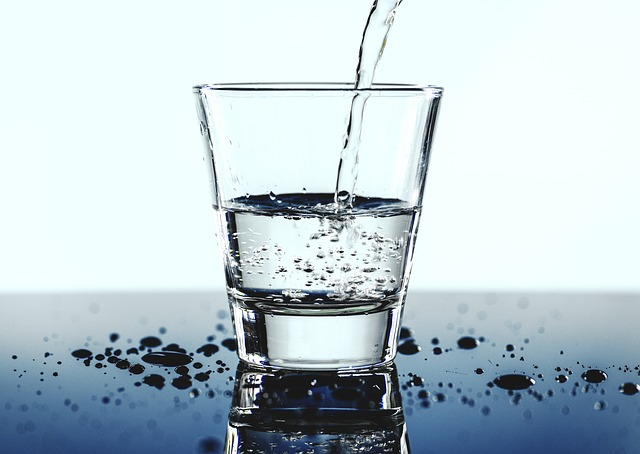

# Ogólne przedstawienie problemu oraz zestawu danych

## Przedstawienie problemu

Wszyscy wiemy jak ważna jest woda w naszym życiu. Na świecie panuje kryzys wodny. W niektórych krajach, które kupują wodę pitną i przewożą ją w tankowcach. Kryzys będzie się powiększał w przyszłości.

## Informacje o zbiorze danych

Zbiór danych składa się z 10 zmiennych, 9 z nich jest numerycznych, a jedna kategoryczna (0 lub 1) woda zdatna do picia (1), woda nie zdatna do picia (0).

## Zawartość

1. **ph Value:** PH jest ważnym parametrem w ocenie równowagi kwasowo-zasadowej wody.
2. **Hardness:** Twardość jest powodowana głównie przez sole wapnia i magnezu.
3. **Solids (Total dissolved solids - TDS)**: (Ciała stałe) Woda ma zdolność rozpuszczania szerokiej gamy nieorganicznych i niektórych organicznych minerałów lub soli, takich jak potas, wapń, sód, wodorowęglany, chlorki, magnez, siarczany itp.
4. **Chloramines:** Chlor i chloramina to główne środki dezynfekujące stosowane w publicznych systemach wodociągowych..
5. **Sulfate:** Siarczany to naturalnie występujące substancje, które znajdują się w minerałach, glebie i skałach.
6. **Conductivity:** (Przewodność) Czysta woda nie jest dobrym przewodnikiem prądu elektrycznego, a raczej dobrym izolatorem. Wzrost stężenia jonów poprawia przewodnictwo elektryczne wody.
7. **Organic_carbon:** Całkowity węgiel organiczny (TOC) w wodach źródłowych pochodzi z rozkładającej się naturalnej materii organicznej (NOM), a także ze źródeł syntetycznych.
8. **Trihalomethanes:** THM to substancje chemiczne, które można znaleźć w wodzie uzdatnionej chlorem.
9. **Turbidity:** (Mętność) Zmętnienie wody zależy od ilości ciał stałych obecnych w stanie zawieszonym.
10. **Potability:** (Zdatność do picia) Wskazuje, czy woda jest bezpieczna do spożycia przez ludzi, gdzie 1 oznacza zdatną do picia, a 0 oznacza niezdatną do picia.

# Wczytywanie i analiza danych

### Wczytywanie danych

```r
df <- read.csv('water_potability.csv') %>% glimpse()
```

```
## Rows: 3,276
## Columns: 10
## $ ph              <dbl> NA, 3.716080, 8.099124, 8.316766, 9.092223, 5.584087, ~
## $ Hardness        <dbl> 204.8905, 129.4229, 224.2363, 214.3734, 181.1015, 188.~
## $ Solids          <dbl> 20791.32, 18630.06, 19909.54, 22018.42, 17978.99, 2874~
## $ Chloramines     <dbl> 7.300212, 6.635246, 9.275884, 8.059332, 6.546600, 7.54~
## $ Sulfate         <dbl> 368.5164, NA, NA, 356.8861, 310.1357, 326.6784, 393.66~
## $ Conductivity    <dbl> 564.3087, 592.8854, 418.6062, 363.2665, 398.4108, 280.~
## $ Organic_carbon  <dbl> 10.379783, 15.180013, 16.868637, 18.436524, 11.558279,~
## $ Trihalomethanes <dbl> 86.99097, 56.32908, 66.42009, 100.34167, 31.99799, 54.~
## $ Turbidity       <dbl> 2.963135, 4.500656, 3.055934, 4.628771, 4.075075, 2.55~
## $ Potability      <int> 0, 0, 0, 0, 0, 0, 0, 0, 0, 0, 0, 0, 0, 0, 0, 0, 0, 0, ~
```

### Zamiana zmiennej “Potability” na zmienną kategoryczną oraz zerknięcie na dane

```r
df <- df %>% mutate(Potability = as.factor(Potability))
colnames(df) <- tolower(colnames(df))
glimpse(df)
```

```
## Rows: 3,276
## Columns: 10
## $ ph              <dbl> NA, 3.716080, 8.099124, 8.316766, 9.092223, 5.584087, ~
## $ hardness        <dbl> 204.8905, 129.4229, 224.2363, 214.3734, 181.1015, 188.~
## $ solids          <dbl> 20791.32, 18630.06, 19909.54, 22018.42, 17978.99, 2874~
## $ chloramines     <dbl> 7.300212, 6.635246, 9.275884, 8.059332, 6.546600, 7.54~
## $ sulfate         <dbl> 368.5164, NA, NA, 356.8861, 310.1357, 326.6784, 393.66~
## $ conductivity    <dbl> 564.3087, 592.8854, 418.6062, 363.2665, 398.4108, 280.~
## $ organic_carbon  <dbl> 10.379783, 15.180013, 16.868637, 18.436524, 11.558279,~
## $ trihalomethanes <dbl> 86.99097, 56.32908, 66.42009, 100.34167, 31.99799, 54.~
## $ turbidity       <dbl> 2.963135, 4.500656, 3.055934, 4.628771, 4.075075, 2.55~
## $ potability      <fct> 0, 0, 0, 0, 0, 0, 0, 0, 0, 0, 0, 0, 0, 0, 0, 0, 0, 0, ~
```

```r
summary(df)
```

```
##        ph            hardness          solids         chloramines
##  Min.   : 0.000   Min.   : 47.43   Min.   :  320.9   Min.   : 0.352
##  1st Qu.: 6.093   1st Qu.:176.85   1st Qu.:15666.7   1st Qu.: 6.127
##  Median : 7.037   Median :196.97   Median :20927.8   Median : 7.130
##  Mean   : 7.081   Mean   :196.37   Mean   :22014.1   Mean   : 7.122
##  3rd Qu.: 8.062   3rd Qu.:216.67   3rd Qu.:27332.8   3rd Qu.: 8.115
##  Max.   :14.000   Max.   :323.12   Max.   :61227.2   Max.   :13.127
##  NA's   :491
##     sulfate       conductivity   organic_carbon  trihalomethanes
##  Min.   :129.0   Min.   :181.5   Min.   : 2.20   Min.   :  0.738
##  1st Qu.:307.7   1st Qu.:365.7   1st Qu.:12.07   1st Qu.: 55.845
##  Median :333.1   Median :421.9   Median :14.22   Median : 66.622
##  Mean   :333.8   Mean   :426.2   Mean   :14.28   Mean   : 66.396
##  3rd Qu.:360.0   3rd Qu.:481.8   3rd Qu.:16.56   3rd Qu.: 77.337
##  Max.   :481.0   Max.   :753.3   Max.   :28.30   Max.   :124.000
##  NA's   :781                                     NA's   :162
##    turbidity     potability
##  Min.   :1.450   0:1998
##  1st Qu.:3.440   1:1278
##  Median :3.955
##  Mean   :3.967
##  3rd Qu.:4.500
##  Max.   :6.739
##
```

### Brakujące wartośći

Jak można zauważyć w zbiorze danych istnieją brakujące wartości, teraz się nimi zajmiemy.

```r
df %>% summarise_all(~ sum(is.na(.)))
```

```
##    ph hardness solids chloramines sulfate conductivity organic_carbon
## 1 491        0      0           0     781            0              0
##   trihalomethanes turbidity potability
## 1             162         0          0
```

### Wykres gęstości braukjących wartości

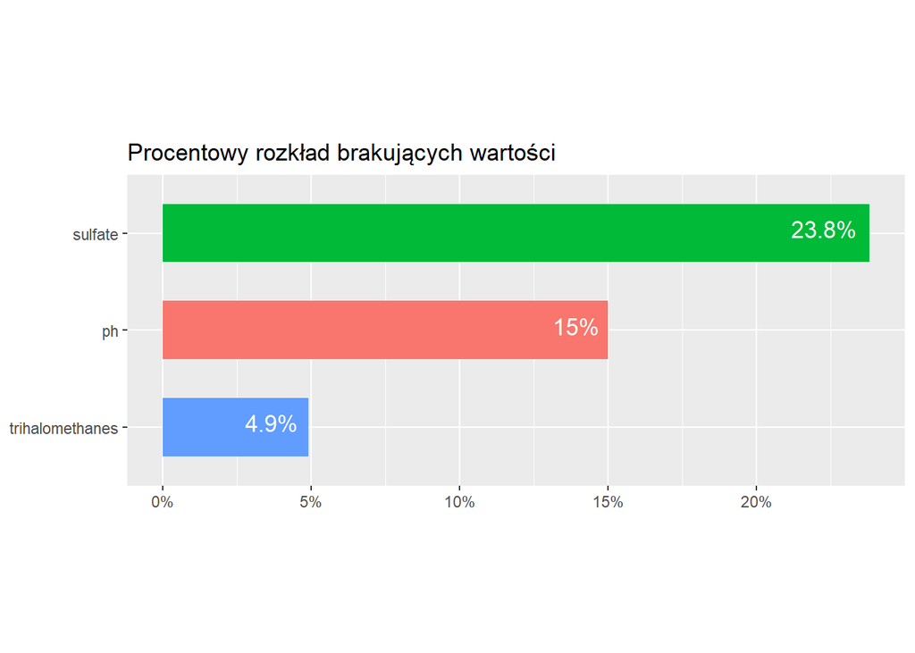

### Zamiana brakujących danych poprzez średnią

```r
for(i in 1:9){
  df[is.na(df[,i]),i] <- mean(df[, i], na.rm = T)
}
```

### Wykres rozkładu zdatności wody do picia

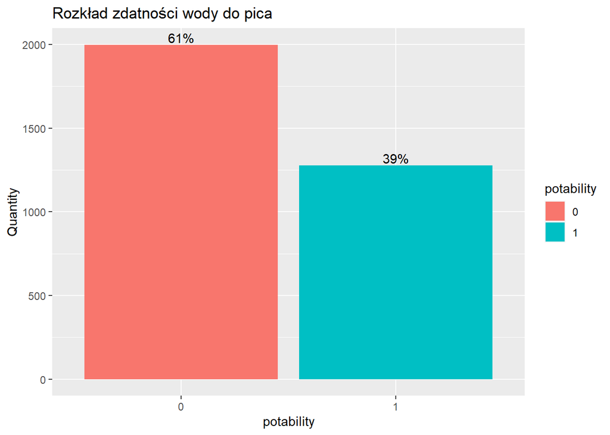

### Wielowymiarowy wykres gęstości

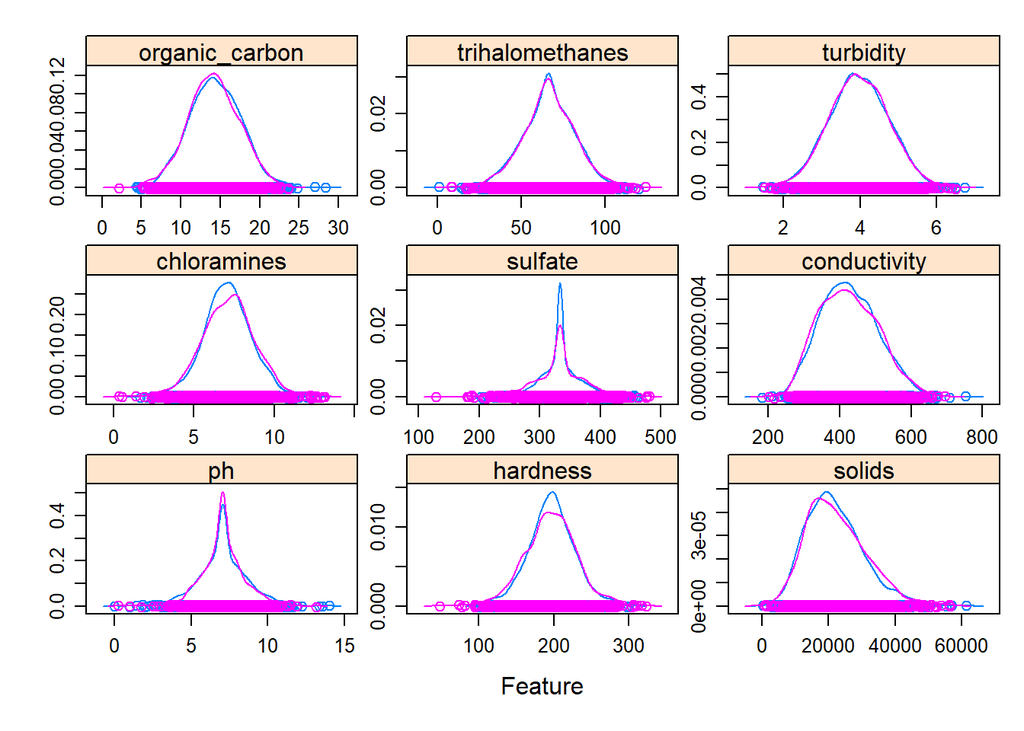

```r
scales <- list(x=list(relation="free"), y=list(relation="free"))
featurePlot(x=df[,1:9],y=df[,10], plot = "density", scales = scales)
```

### Wielowymiarowy wykres pudełkowy

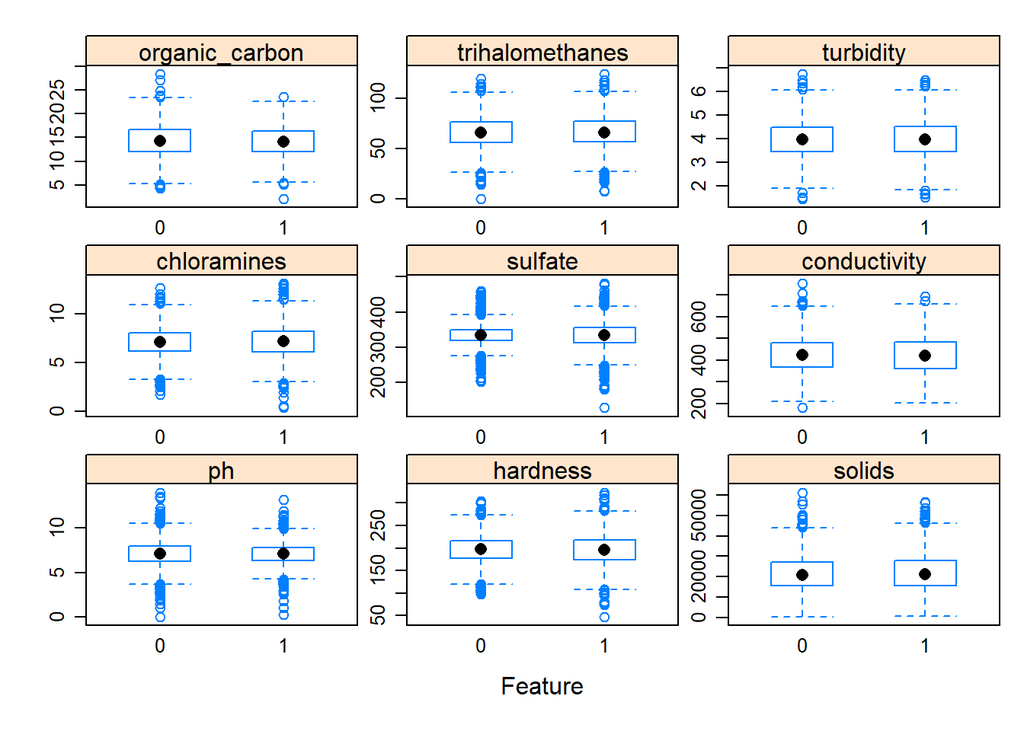

```r
scales <- list(x=list(relation="free"), y=list(relation="free"))
featurePlot(x=df[,1:9],y=df[,10], plot = "box", scales = scales)
```

### Wykres korelacji

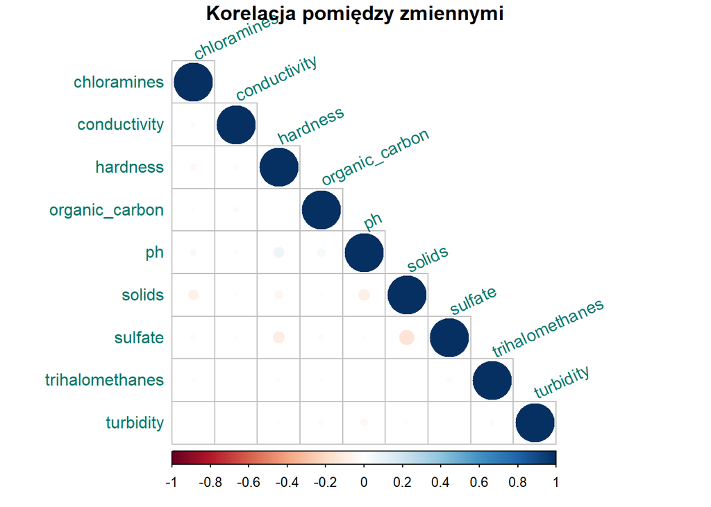

```r
corrplot(
  cor(df[, -10]),
  type = "lower",
  method = "circle",
  number.cex = .9,
  order = "alphabet",
  tl.col = "#00796B",
  tl.srt = 25,
  title = "\nKorelacja pomiędzy zmiennymi"
)
```

# Tworzenie modelu

### Utworzenie danych do trenowania i testowania

```r
train_index <- createDataPartition(df$potability, p = 0.8, list = F)
test_set <- df[-train_index,]
training_set <- df[train_index,]
summary(training_set)
```

```
##        ph            hardness          solids         chloramines
##  Min.   : 0.000   Min.   : 47.43   Min.   :  320.9   Min.   : 0.352
##  1st Qu.: 6.277   1st Qu.:176.97   1st Qu.:15759.5   1st Qu.: 6.115
##  Median : 7.081   Median :196.93   Median :21039.4   Median : 7.109
##  Mean   : 7.066   Mean   :196.66   Mean   :22079.5   Mean   : 7.097
##  3rd Qu.: 7.845   3rd Qu.:217.70   3rd Qu.:27360.2   3rd Qu.: 8.095
##  Max.   :14.000   Max.   :317.34   Max.   :61227.2   Max.   :13.127
##     sulfate       conductivity   organic_carbon  trihalomethanes
##  Min.   :129.0   Min.   :201.6   Min.   : 2.20   Min.   :  0.738
##  1st Qu.:317.1   1st Qu.:365.8   1st Qu.:12.03   1st Qu.: 56.412
##  Median :333.8   Median :422.0   Median :14.20   Median : 66.396
##  Mean   :333.7   Mean   :426.0   Mean   :14.24   Mean   : 66.361
##  3rd Qu.:350.4   3rd Qu.:481.9   3rd Qu.:16.52   3rd Qu.: 76.676
##  Max.   :475.7   Max.   :695.4   Max.   :28.30   Max.   :124.000
##    turbidity     potability
##  Min.   :1.450   0:1599
##  1st Qu.:3.441   1:1023
##  Median :3.961
##  Mean   :3.966
##  3rd Qu.:4.498
##  Max.   :6.495
```

### 10-krotna walidacja krzyżowa metodą “CV”

```r
control <- trainControl(method = "cv", number = 10)
metric = "Accuracy"
```

### Tworzenie modeli

```r
#Linear Discriminant Analysis (LDA)
set.seed(7)
fit.lda <- train(potability ~.,data=training_set,method="lda",metric=metric,trControl=control)
#Classification and Regression Trees (CART).
set.seed(7)
fit.cart <- train(potability ~.,data=training_set,method="rpart",metric=metric,trControl=control)
#k-Nearest Neighbors (kNN).
set.seed(7)
fit.knn <- train(potability ~.,data=training_set,method="knn",metric=metric,trControl=control)
#Support Vector Machines (SVM) with a linear kernel.
set.seed(7)
fit.svm <- train(potability ~.,data=training_set,method="svmRadial",metric=metric,trControl=control)
#Random Forest (RF)
set.seed(7)
fit.rf <- train(potability ~.,data=training_set,method="rf",metric=metric,trControl=control)
```

### Wybranie najlepszego modelu

```r
results <- resamples(list(lda=fit.lda, cart=fit.cart, knn=fit.knn, svm=fit.svm, rf=fit.rf))
summary(results)
```

```
##
## Call:
## summary.resamples(object = results)
##
## Models: lda, cart, knn, svm, rf
## Number of resamples: 10
##
## Accuracy
##           Min.   1st Qu.    Median      Mean   3rd Qu.      Max. NA's
## lda  0.6083650 0.6095683 0.6106870 0.6102215 0.6106870 0.6121673    0
## cart 0.6045627 0.6167714 0.6374046 0.6380901 0.6539634 0.6793893    0
## knn  0.5399240 0.5602246 0.5782443 0.5724699 0.5872275 0.5954198    0
## svm  0.6311787 0.6615970 0.6679389 0.6705140 0.6870229 0.7011494    0
## rf   0.6501901 0.6631825 0.6761820 0.6773741 0.6832061 0.7126437    0
##
## Kappa
##             Min.     1st Qu.     Median        Mean    3rd Qu.       Max. NA's
## lda   0.00000000 0.000000000 0.00000000 0.001178811 0.00000000 0.01178811    0
## cart  0.06872038 0.101657393 0.12686721 0.132730044 0.15684343 0.22045905    0
## knn  -0.07108478 0.005958335 0.03690175 0.030653227 0.07411995 0.09099241    0
## svm   0.13805453 0.184748894 0.20887130 0.216498624 0.25433847 0.29838710    0
## rf    0.20245237 0.218215867 0.23921108 0.248856579 0.26013014 0.33709235    0
```

Wybieramy model RandomForest i na jego podstawie zrobimy przewidywanie

### Przewidywanie

```r
predictions <- predict(fit.rf, test_set)
confusionMatrix(predictions, test_set$potability)
```

```
## Confusion Matrix and Statistics
##
##           Reference
## Prediction   0   1
##          0 355 176
##          1  44  79
##
##                Accuracy : 0.6636
##                  95% CI : (0.626, 0.6998)
##     No Information Rate : 0.6101
##     P-Value [Acc > NIR] : 0.002648
##
##                   Kappa : 0.2201
##
##  Mcnemar's Test P-Value : < 2.2e-16
##
##             Sensitivity : 0.8897
##             Specificity : 0.3098
##          Pos Pred Value : 0.6685
##          Neg Pred Value : 0.6423
##              Prevalence : 0.6101
##          Detection Rate : 0.5428
##    Detection Prevalence : 0.8119
##       Balanced Accuracy : 0.5998
##
##        'Positive' Class : 0
##
```

### Cechy wody, które dla naszego modelu są najważniejsze przy dokonywaniu predykcji

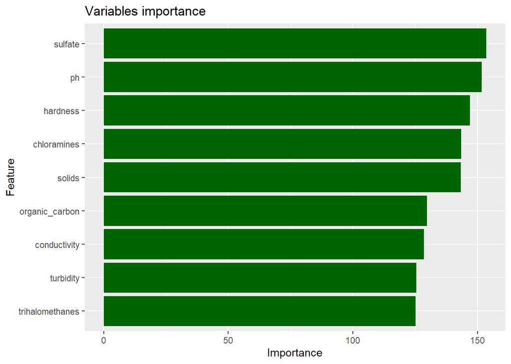

```r
vars.imp <- varImp(fit.rf, scale = F)
ggplot(vars.imp) +
  geom_col(fill = "dark green", size = 1) +
  labs(title = "Variables importance")
```